# Housing Prices? How predictable!

James Banasiak (jamesmb3), Ryan Epp (ryanepp2) and Nana Tark (ytark2)

Summer 2019

# Introduction

In this data analysis project we explore the dataset from the *House Prices: Advanced Regression Techniques* competition held on [Kaggle](https://www.kaggle.com/c/house-prices-advanced-regression-techniques). The dataset describes residential homes in Ames, Iowa. The goal of is project (and the Kaggle competition) is to predict the sale price of a home based on it’s other attributes. Theses attributes are represented in the dataset by an extensive 79 variables, including everything from the number of bathrooms, to the material the roof is made out of, to the year the home was built.

Our primary goal is to build a model which can predict house prices as accurately as possible. We want our model to work well with previously unseen examples. So to avoid overfitting, we will use cross validation accuracy to evaluate our candidate models.

As a secondary goal, we’d like our model to be stable and interperatable so we will also consider BIC, and Adjusted $R^2$ when selecting a best model.

# Methods

## Data Preparation

First, we load the training data and extract the number of samples and the feature names:

```r
train_data = read.csv('data/train.csv')
n = nrow(train_data)
features = setdiff(colnames(train_data), c("Id", "SalePrice"))
```

The housing dataset includes **79 features** and **1460 samples.**

### Dealing with Missing Predictor Values

Naturally, we expect that some examples are missing features, let’s try removing those samples and see how much data we’d have left to work with:

```r
train_data_omit_na = na.omit(train_data)
nrow(train_data_omit_na)
```

```
## [1] 0
```

Bummer! It appears every sample has is missing at least one feature. So we can’t simply omit them or we’ll have nothing left to work with! For factor variables with missing values, we can simply create a new *`other`* category to fill in for *`NA`* values.

```r
other_category = 'other'
for (f in features) {
  if (is.factor(train_data[[f]]) && any(is.na(train_data[[f]]))) {
    levels(train_data[[f]]) = c(levels(train_data[[f]]), other_category)
    train_data[[f]][is.na(train_data[[f]])] = other_category
  }
}

# Try omitting samples with missing features again:
train_data_omit_na = na.omit(train_data)
nrow(train_data_omit_na)
```

```
## [1] 1121
```

This appears to solve most of the problem, but we’re still losing 339 samples, since they have missing numeric feature values. Since they’re a large portion (23% of the dataset), we don’t want to ignore them. Unfortunately, finding suitable replacement values for numeric features is more difficult.

Let’s see which features have missing values:

```r
Filter(function (f) any(is.na(train_data[[f]])), features)
```

```
## [1] "LotFrontage" "MasVnrArea"  "GarageYrBlt"
```

Great, we only need to deal with missing values for 3 numeric features. Let’s replace the *`NA`* values of these features with sensible defaults.

For `MasVnrArea`, the masonry veneer area in square feet, we have a large number of examples with a value of 0, so that should be a decent replacement. Since it doesn’t seem especially important, we might also consider dropping the feature entirely instead of the samples.

```r
train_data$MasVnrArea[is.na(train_data$MasVnrArea)] = 0
```

Since `GarageYrBlt` and `YearBuilt` are highly correlated (0.8235195) and they’re identical 60% of the time, we’ll simply replace missing `GarageYrBlt` values with `YearBuilt` values.

```r
train_data$GarageYrBlt[is.na(train_data$GarageYrBlt)] = train_data$YearBuilt[is.na(train_data$GarageYrBlt)]
```

Coming up with replacement values for `LotFrontage` (linear feet of street connected to property) is much more difficult. It seems too important of a feature to simply remove. There are also no cases where the value is 0, and so no obvious replacement value.

There are a few variables like `LotArea`, `LotShape` and `LotConfig` that seem like they might be predictive of `LotFrontage`. Let’s quickly build a model to predict `LotFrontage` and then use it to fill in our missing values.

```r
lot_frontage_model = lm(LotFrontage ~ log(LotArea) + LotArea:LotConfig + LotShape + LandSlope + YearBuilt + BldgType, data = train_data_omit_na)
```

We can be confident the `lot_frontage_model` above is doing a good job predicting `LotFrontage` because:

- The p-value of the significance of regression test is extremely small.
- The adjusted $R^2$ is fairly large: 0.583933
- We’re using a small number of predictors without higher degree polynomials so we aren’t especially concerned with overfitting.

If we wanted to be even more confident, we might check the cross validated RMSE, but because we’re only using this model to fill in missing values, we won’t spend too much time on it.

Now we can fillin the missing `LotFrontage` values:

```r
train_data$LotFrontage[is.na(train_data$LotFrontage)] = predict(lot_frontage_model, newdata = train_data[is.na(train_data$LotFrontage),])

# Check if there are any remaining NA values in the training data:
any(is.na(train_data))
```

```
## [1] FALSE
```

**Success!** We’ve managed to replace all of the missing values without losing any training samples.

### Creating Additional Factor Variables

When we loaded the dataset, R decided which predictors were numeric and which were factors. Some predictors that R considers numeric, might work better as factor variables. For example, the price difference between a 0 and a 2 car garage is likely different than the price difference between a 2 and a 4 car garage.

```r
for (f in features) {
  # We'll add any numeric predictor with less than 12 unique values as a factor variable
  if (!is.factor(train_data[[f]]) && length(unique(train_data[[f]])) <= 12) {
    train_data[[paste(f, 'Fctr', sep = "")]] = as.factor(train_data[[f]])
  }
}

# Update `features`:
features = setdiff(colnames(train_data), c("Id", "SalePrice"))
```

Great, we’ve added 14 new factor variables for a total of **93 features**.

### Removing Categories with Few Samples

Some categorical variables have categories with very few samples. These cause issues in *R* when doing cross-validation because categories may exist in the cross-validation set that weren’t in the training set and the training set may contain factors with only one category. Since they’re a realatively small part of the data, it should be safe to just remove these categories along with predictors where most of the samples are in a single class.

```r
# Remove categories that contain < 5% of the samples:
category_cutoff = n * 0.05
for (f in features) {
  if (is.factor(train_data[[f]])) {
    for (category in levels(train_data[[f]])) {
      samples_in_cat = sum(na.omit(train_data[[f]]) == category)
      if (samples_in_cat < category_cutoff) {
        levels(train_data[[f]]) = c(levels(train_data[[f]]), other_category)
        train_data[[f]][train_data[[f]] == category] = other_category
      }
    }
  }
}

# Remove predictors where > 95% of the samples are in 1 category:
feature_cutoff = n * 0.95
for (f in features) {
  if (is.factor(train_data[[f]])) {
    if (length(levels(train_data[[f]])) == 1) {
      train_data = train_data[,!(names(train_data) == f)]
    } else {
      for (category in levels(train_data[[f]])) {
        samples_in_cat = sum(na.omit(train_data[[f]]) == category)
        if (samples_in_cat > feature_cutoff) {
          train_data = train_data[,!(names(train_data) == f)]
        }
      }
    }
  }
}
```

## Data Exploration

We want to better understand what our data looks like before we dive into model building.

First we notice that our response variable `SalePrice` has a righ skew. A log transform can be used to adjust and normalize the distribution. This will likely come in handy when building our models.

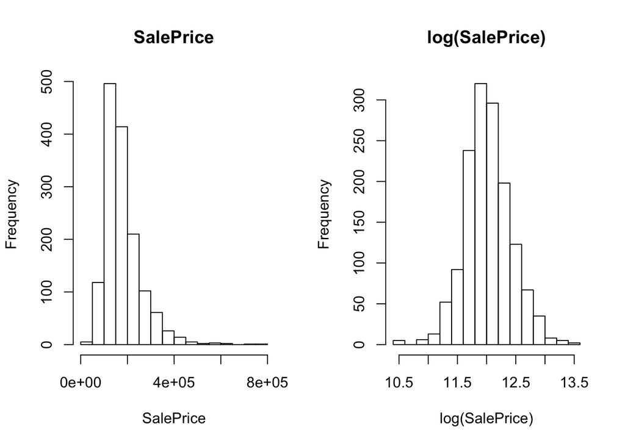

```r
par(mfrow=c(1,2))
hist(train_data$SalePrice,main = "SalePrice", xlab = 'SalePrice')
hist(log(train_data$SalePrice), main = "log(SalePrice)", xlab = 'log(SalePrice)')
```

We also check the distributions of the numeric predictors and note than many become more *normal* when a log transformation is applied.

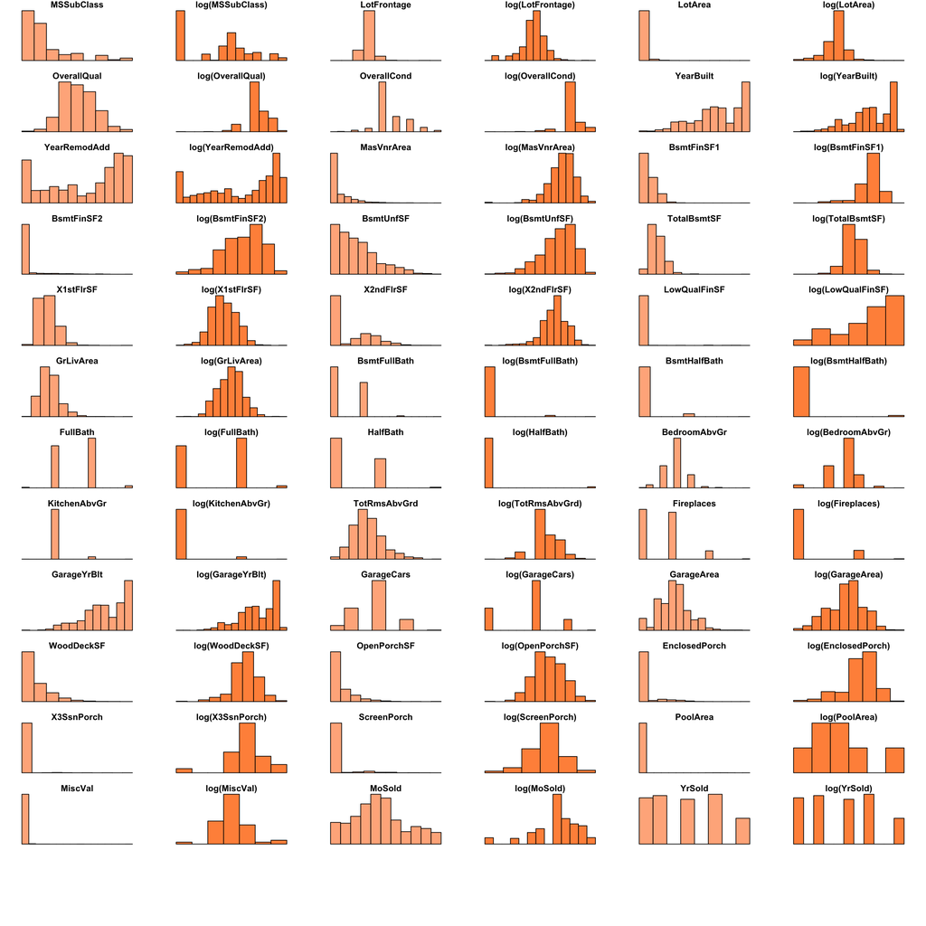

```r
numeric_var_count = length(which(sapply(train_data, is.numeric)))
par(mfrow=c(ceiling(numeric_var_count*2 / 6),6), mar=c(1,2,1,2))
for (f in features) {
  if (is.numeric(train_data[[f]])) {
    hist(train_data[[f]], main = f, xaxt='n', yaxt='n', xlab = NA, ylab  = NA, col = '#ffb38a')
    hist(log(train_data[[f]]), main = paste0("log(",f,")"), xaxt='n', yaxt='n', xlab = NA, ylab  = NA, col = '#ff9248')
  }
}
```

We then quiclky inspect the correlations between the numeric predictors in our dataset to determine which might be useful in predicting `SalePrice` and which might have collinearity issues:

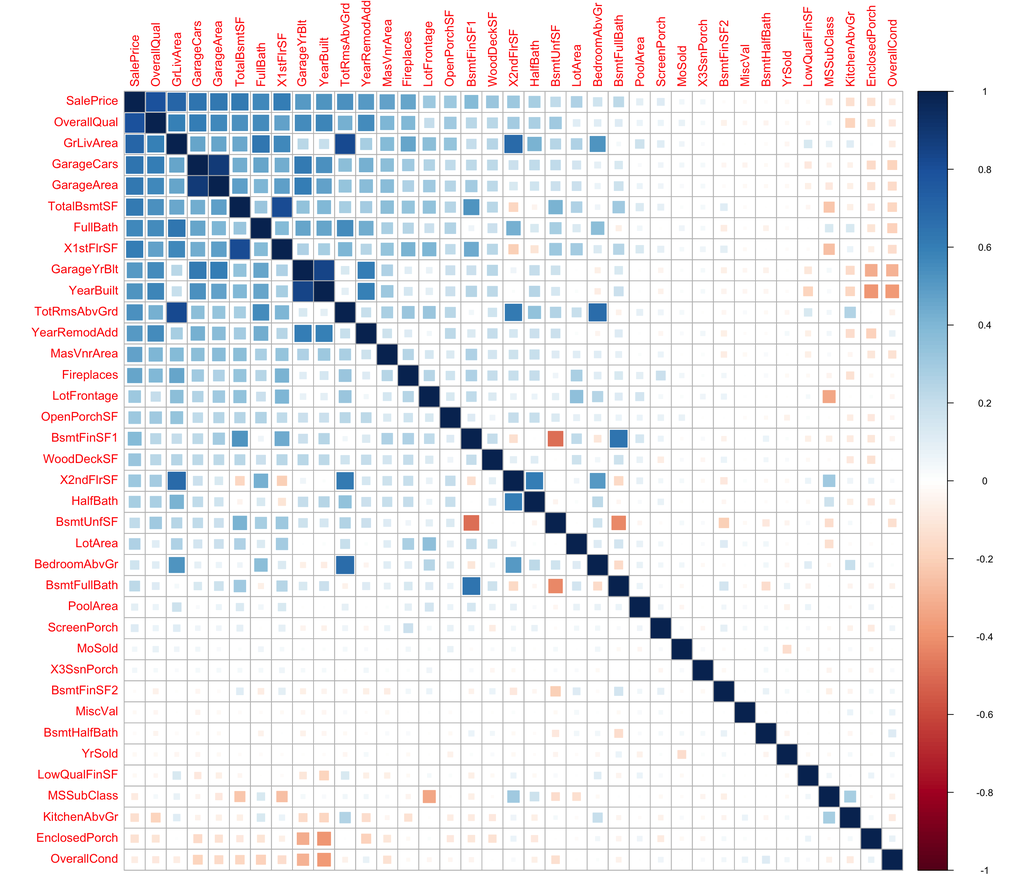

```r
numeric_variables <- train_data[which(sapply(train_data, is.numeric))]
numeric_variables <- subset(numeric_variables, select = -c(Id))
correlations <- cor(numeric_variables)
corrplot(correlations, method="square", order ="FPC")
```

Next we visualize the numeric predictors that are most correlated with `SalePrice`:

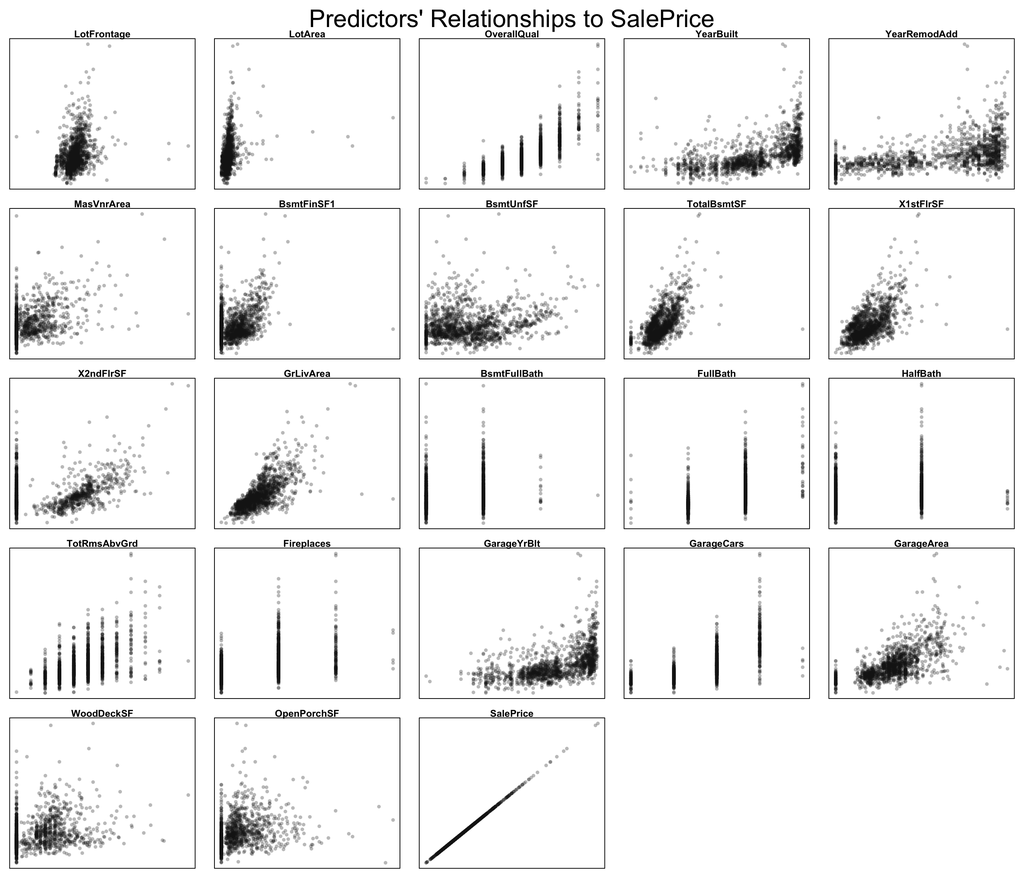

```r
correlated_indices = abs(correlations['SalePrice',]) > 0.2
correlated_predictors = names(correlations['SalePrice',correlated_indices])
par(mfrow = c(ceiling(length(correlated_predictors) / 5.0), 5), mar=c(1,1,1,1), oma = c(0, 0, 3, 0))
for (cor_pred in correlated_predictors) {
  plot(train_data[[cor_pred]], train_data$SalePrice,
       main=cor_pred, col=rgb(0.1,0.1,0.1,0.3), pch=16,
       xaxt='n', yaxt='n', xlab = NA, ylab  = NA)
}
mtext("Predictors' Relationships to SalePrice", outer=TRUE, cex = 2)
```

## Model Evaluation

As an evaluation metric, the Kaggle competition uses Root-Mean-Squared-Error (RMSE) on the *logorithm of the predicted and actual sale prices*. Taking the logorithm ensures that expensive houses don’t have more of an impact on RMSE than cheap houses.

We’ll use this same metric as our primary quality indicator. To ensure we don’t overfit, we’ll apply it on a 5-fold cross validation set. We’ll also keep our eye on BIC, Adjusted $R^2$ and a few other metrics.

```r
get_bp_decision = function(model, alpha = 0.01) {
  decide = unname(bptest(model)$p.value < alpha)
  ifelse(decide, "Reject", "Fail to Reject")
}

get_shapiro_decision = function(model, alpha = 0.01) {
  decide = unname(shapiro.test(resid(model))$p.value < alpha)
  ifelse(decide, "Reject", "Fail to Reject")
}

get_log_rmse = function(observed, predicted) {
  sqrt(mean((log(predicted) - log(observed)) ^ 2))
}

get_cv_log_rmse = function(model_formula, folds = 5, response_transform_func = I, data = train_data) {
  total_rmse = 0
  for (i in 1:folds) {
    idx = sample(c(TRUE, FALSE), n, replace=TRUE, prob=c(0.8, 0.2))
    training_set = data[idx,]
    cv_set = data[!idx,]
    model = train(model_formula, data=training_set, method="glm")
    cv_predicted = predict(model, newdata = cv_set)
    # For stability, ignore all predictions are < 1.0
    nan_indices = is.nan(log(cv_predicted))
    cv_predicted = cv_predicted[!nan_indices]
    cv_predicted = response_transform_func(cv_predicted)
    total_rmse = total_rmse + get_log_rmse(cv_set$SalePrice[!nan_indices], cv_predicted)
  }
  total_rmse / folds
}

evaluate_model = function(name, model, response_transform_func = I, data = train_data) {
  set.seed(42)
  data.frame(Model = name,
             CV.Log.RMSE = get_cv_log_rmse(model$terms,
                                           response_transform_func = response_transform_func,
                                           data = data),
             Adj.R2 = rsq(model, adj=TRUE),
             BIC = BIC(model),
             Coefficients = length(coef(model)),
             Shapiro.Decision = get_shapiro_decision(model),
             BP.Decision = get_bp_decision(model)
             )
}
```

## Model Building

### Baseline Models

```r
# Start with a simple, naive model using all predictors added together
additive_large = lm(SalePrice ~ ., data = train_data)
additive_large_eval = evaluate_model("Additive Large", additive_large)
kable(additive_large_eval)
```

| Model | CV.Log.RMSE | Adj.R2 | BIC | Coefficients | Shapiro.Decision | BP.Decision |
| --- | --- | --- | --- | --- | --- | --- |
| Additive Large | 0.174783 | 0.880485 | 35015.8 | 172 | Reject | Reject |

```r
# Variables were selected based on the results of the Data Exploration section above
additive_small = lm(SalePrice ~
                      LotArea + X1stFlrSF + X2ndFlrSF + MasVnrArea + BedroomAbvGr + OverallQual +
                      OverallCond  + ExterQual + KitchenQual + BsmtQual + BsmtExposure + ScreenPorch +
                      Fireplaces + MSZoning + YearBuilt, data = train_data)
additive_small_eval = evaluate_model("Additive Small", additive_small)
kable(additive_small_eval)
```

| Model | CV.Log.RMSE | Adj.R2 | BIC | Coefficients | Shapiro.Decision | BP.Decision |
| --- | --- | --- | --- | --- | --- | --- |
| Additive Small | 0.1712864 | 0.8266707 | 34694.53 | 25 | Reject | Reject |

### Parameter Search using BIC

The small baseline model also has a better BIC. So it looks like BIC might be a good metric to use to avoid overfitting. Next, we’ll use BIC to do a backwards parameter search starting from `additive_large` model.

```r
additive_bic_backward = step(additive_large, k = log(n), direction = 'backward', trace = 0)
additive_bic_backward_eval = evaluate_model("Additive Backward BIC", additive_bic_backward)
kable(additive_bic_backward_eval)
```

| Model | CV.Log.RMSE | Adj.R2 | BIC | Coefficients | Shapiro.Decision | BP.Decision |
| --- | --- | --- | --- | --- | --- | --- |
| Additive Backward BIC | 0.1592838 | 0.8720961 | 34394.81 | 48 | Reject | Reject |

### Transformations

Doing a parameter search using backwards BIC managed improve our results, but it still fails the Shapiro-Wilks and Breusch-Pagan tests. This suggests we might be able to achieve better results by applying some transformations to our the response and/or predictors.

Based on the graphs in the *Data Exploration* section above, it appears that our model would benefit from log transforming `SalePrice`:

```r
log_response = lm(log(SalePrice) ~ ., data = train_data)
# As before, we'll perfrom backwards BIC to remove excess predictors
log_response_bic_backward = step(log_response, k = log(n), direction = 'backward', trace = 0)
log_response_bic_backward_eval = evaluate_model("Log Response Backward BIC", log_response_bic_backward, response_transform_func = exp)
kable(log_response_bic_backward_eval)
```

| Model | CV.Log.RMSE | Adj.R2 | BIC | Coefficients | Shapiro.Decision | BP.Decision |
| --- | --- | --- | --- | --- | --- | --- |
| Log Response Backward BIC | 0.1601717 | 0.8869986 | -1455.157 | 41 | Reject | Reject |

Note that because we’ve transformed the response variable, we can’t compare BIC with the previous models.

Next, we’ll try log transforming some of the numeric predictors and and only using those that appear to be significant:

```r
should_log_transform = c('MSSubClass','LotArea','BsmtFinSF1','BsmtFinSF2','BsmtUnfSF','TotalBsmtSF','X1stFlrSF','X2ndFlrSF','LowQualFinSF','GrLivArea','BedroomAbvGr','TotRmsAbvGrd','GarageArea','WoodDeckSF','OpenPorchSF','EnclosedPorch','X3SsnPorch','ScreenPorch','PoolArea','MiscVal','MoSold')

log_train_data = train_data
tmp = sapply(should_log_transform, function(var){
  log_train_data[[var]] <<- log(log_train_data[[var]] + 1)
})

# Fit a linear model with the new log-transformed data
tmp_model = lm(log(SalePrice) ~ . - Id - MSSubClass, data = log_train_data)
pvals = coef(summary(tmp_model))[,"Pr(>|t|)"]

# Select predictors with pvals less than .001 and create a new formula
significant_preds = data.frame(var = names(pvals[pvals<0.001]))
all_factor_column_names = build_column_factor_map(d = log_train_data)
pval_cols_used = unique(merge(all_factor_column_names, significant_preds, by.x = "var", by.y = "var")$val)
log_pval_model_formula = as.formula(paste("log(SalePrice) ~ ", paste(pval_cols_used, collapse="+")))

log_pval_model = lm(log_pval_model_formula, data = log_train_data)
log_pval_model_eval = evaluate_model("Log Response and Predictors w/ P-value", log_pval_model, response_transform_func = exp, data = log_train_data)
kable(log_pval_model_eval)
```

| Model | CV.Log.RMSE | Adj.R2 | BIC | Coefficients | Shapiro.Decision | BP.Decision |
| --- | --- | --- | --- | --- | --- | --- |
| Log Response and Predictors w/ P-value | 0.165573 | 0.8472417 | -1102.703 | 28 | Reject | Reject |

We’ll also try adding some polynomial transformations to the predictors based on the graphs in the Data Exploration section. We’ll also keep the log transform of the response:

```r
# Modify some predictors that look like they'd benefit from a log transform to ensure stability
modified_train_data = train_data
modified_train_data$WoodDeckSF = modified_train_data$WoodDeckSF + 1
modified_train_data$OpenPorchSF = modified_train_data$OpenPorchSF + 1

poly_transform = lm(log(SalePrice) ~ . + I(OverallQual ^ 2) + I(YearBuilt ^ 2) + I(X1stFlrSF ^ 2) + I(X2ndFlrSF ^ 2) + I(GrLivArea ^ 2) + I(OverallCond ^ 2) + I(GarageArea ^ 2) + I(TotalBsmtSF ^ 2) + I(BsmtFinSF1 ^ 2) + log(LotArea) + I(LotFrontage ^ 2) + I(GarageYrBlt ^ 2) + log(WoodDeckSF) + log(OpenPorchSF), data = modified_train_data)
# Perform backwards BIC to remove excess predictors
poly_transform_backwards_bic = step(poly_transform, k = log(n), direction = 'backward', trace = 0)
poly_transform_backwards_bic_eval = evaluate_model("Log Response, Poly Predictors, Backwards BIC", poly_transform_backwards_bic, response_transform_func = exp, data = modified_train_data)
kable(poly_transform_backwards_bic_eval)
```

| Model | CV.Log.RMSE | Adj.R2 | BIC | Coefficients | Shapiro.Decision | BP.Decision |
| --- | --- | --- | --- | --- | --- | --- |
| Log Response, Poly Predictors, Backwards BIC | 0.1224275 | 0.9133608 | -1843.003 | 41 | Reject | Reject |

# Results

```r
model_results = rbind(additive_large_eval, additive_small_eval, additive_bic_backward_eval, log_response_bic_backward_eval, log_pval_model_eval, poly_transform_backwards_bic_eval)
kable(model_results)
```

| Model | CV.Log.RMSE | Adj.R2 | BIC | Coefficients | Shapiro.Decision | BP.Decision |
| --- | --- | --- | --- | --- | --- | --- |
| Additive Large | 0.1747830 | 0.8804850 | 35015.803 | 172 | Reject | Reject |
| Additive Small | 0.1712864 | 0.8266707 | 34694.528 | 25 | Reject | Reject |
| Additive Backward BIC | 0.1592838 | 0.8720961 | 34394.805 | 48 | Reject | Reject |
| Log Response Backward BIC | 0.1601717 | 0.8869986 | -1455.157 | 41 | Reject | Reject |
| Log Response and Predictors w/ P-value | 0.1655730 | 0.8472417 | -1102.703 | 28 | Reject | Reject |
| Log Response, Poly Predictors, Backwards BIC | 0.1224275 | 0.9133608 | -1843.003 | 41 | Reject | Reject |

```r
best_model = poly_transform_backwards_bic
summary(best_model)
```

```
##
## Call:
## lm(formula = log(SalePrice) ~ MSZoning + Neighborhood + Condition1 +
##     OverallCond + YearRemodAdd + BsmtFinSF1 + BsmtFinSF2 + BsmtUnfSF +
##     CentralAir + X1stFlrSF + X2ndFlrSF + LowQualFinSF + BsmtFullBath +
##     BedroomAbvGr + KitchenAbvGr + Functional + GarageArea + GarageCond +
##     WoodDeckSF + ScreenPorch + SaleCondition + I(OverallQual^2) +
##     I(YearBuilt^2) + I(X1stFlrSF^2) + I(X2ndFlrSF^2) + I(GrLivArea^2) +
##     I(BsmtFinSF1^2) + log(LotArea), data = modified_train_data)
##
## Residuals:
##      Min       1Q   Median       3Q      Max
## -0.87850 -0.05326  0.00254  0.06139  0.51032
##
## Coefficients:
##                        Estimate Std. Error t value Pr(>|t|)
## (Intercept)           6.275e+00  4.316e-01  14.539  < 2e-16 ***
## MSZoningRM           -4.687e-02  1.264e-02  -3.707 0.000218 ***
## MSZoningother        -7.877e-02  1.970e-02  -3.998 6.71e-05 ***
## NeighborhoodEdwards  -5.413e-02  1.719e-02  -3.148 0.001676 **
## NeighborhoodGilbert   1.548e-02  1.723e-02   0.899 0.369025
## NeighborhoodNAmes    -2.385e-02  1.479e-02  -1.612 0.107179
## NeighborhoodNridgHt   6.364e-02  1.796e-02   3.543 0.000409 ***
## NeighborhoodNWAmes   -5.440e-02  1.809e-02  -3.007 0.002686 **
## NeighborhoodOldTown  -2.430e-02  2.033e-02  -1.195 0.232110
## NeighborhoodSawyer   -2.656e-02  1.850e-02  -1.436 0.151344
## NeighborhoodSomerst   1.173e-01  2.230e-02   5.259 1.67e-07 ***
## Neighborhoodother     1.412e-02  1.242e-02   1.137 0.255687
## Condition1Norm        5.040e-02  1.409e-02   3.577 0.000359 ***
## Condition1other      -7.513e-03  1.751e-02  -0.429 0.667951
## OverallCond           4.819e-02  3.690e-03  13.060  < 2e-16 ***
## YearRemodAdd          7.625e-04  2.317e-04   3.291 0.001023 **
## BsmtFinSF1            1.994e-04  2.038e-05   9.784  < 2e-16 ***
## BsmtFinSF2            1.153e-04  2.396e-05   4.811 1.66e-06 ***
## BsmtUnfSF             7.671e-05  1.472e-05   5.211 2.16e-07 ***
## CentralAirY           6.219e-02  1.509e-02   4.121 3.98e-05 ***
## X1stFlrSF             7.920e-04  4.596e-05  17.230  < 2e-16 ***
## X2ndFlrSF             4.995e-04  3.051e-05  16.372  < 2e-16 ***
## LowQualFinSF          5.070e-04  8.009e-05   6.331 3.26e-10 ***
## BsmtFullBath          2.479e-02  8.500e-03   2.916 0.003601 **
```

[output cut: 8 more lines]

```
## SaleConditionPartial  1.363e-01  1.763e-02   7.728 2.06e-14 ***
## SaleConditionother    3.865e-02  2.345e-02   1.648 0.099533 .
## I(OverallQual^2)      5.574e-03  3.307e-04  16.853  < 2e-16 ***
## I(YearBuilt^2)        5.171e-07  5.676e-08   9.110  < 2e-16 ***
## I(X1stFlrSF^2)       -5.533e-08  1.795e-08  -3.083 0.002088 **
## I(X2ndFlrSF^2)        1.310e-07  3.118e-08   4.201 2.82e-05 ***
## I(GrLivArea^2)       -9.094e-08  1.083e-08  -8.397  < 2e-16 ***
## I(BsmtFinSF1^2)      -3.424e-08  8.408e-09  -4.072 4.92e-05 ***
## log(LotArea)          7.625e-02  8.215e-03   9.282  < 2e-16 ***
## ---
## Signif. codes:  0 '***' 0.001 '**' 0.01 '*' 0.05 '.' 0.1 ' ' 1
##
## Residual standard error: 0.1176 on 1419 degrees of freedom
## Multiple R-squared:  0.9157, Adjusted R-squared:  0.9134
## F-statistic: 385.5 on 40 and 1419 DF,  p-value: < 2.2e-16
```

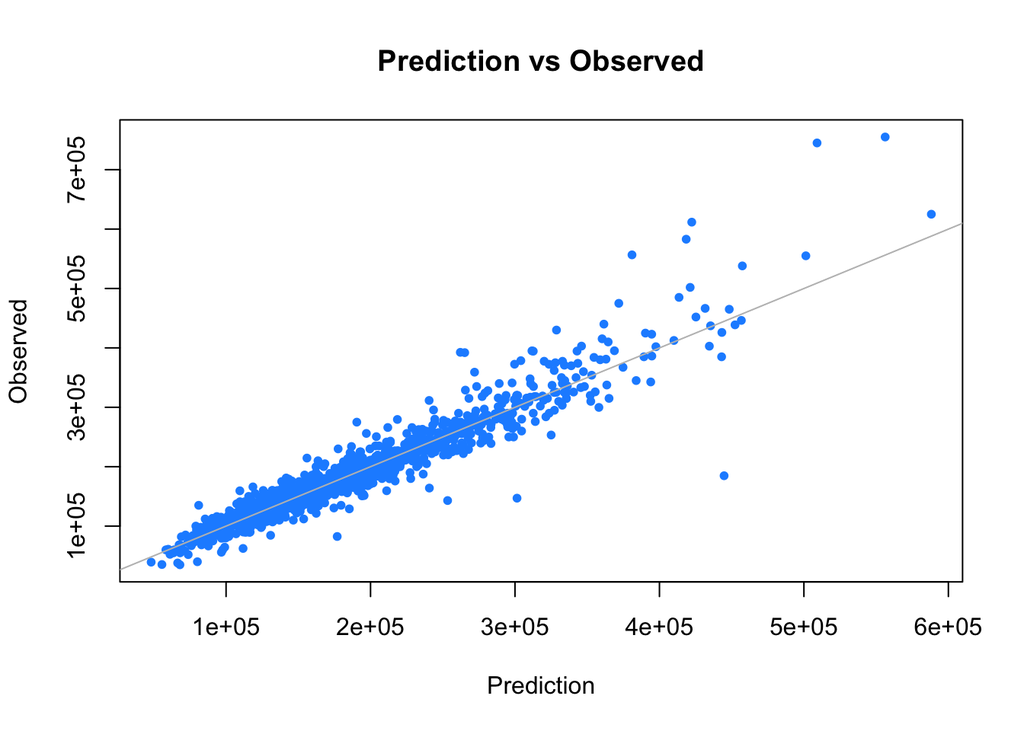

```r
# Visualizing Predicted vs. Observed
plot(exp(fitted(best_model)),
     train_data$SalePrice,
     col = "dodgerblue",
     pch = 20,
     main = "Prediction vs Observed",
     xlab = "Prediction",
     ylab = "Observed"
     )
abline(0,1, col = 'grey')
```

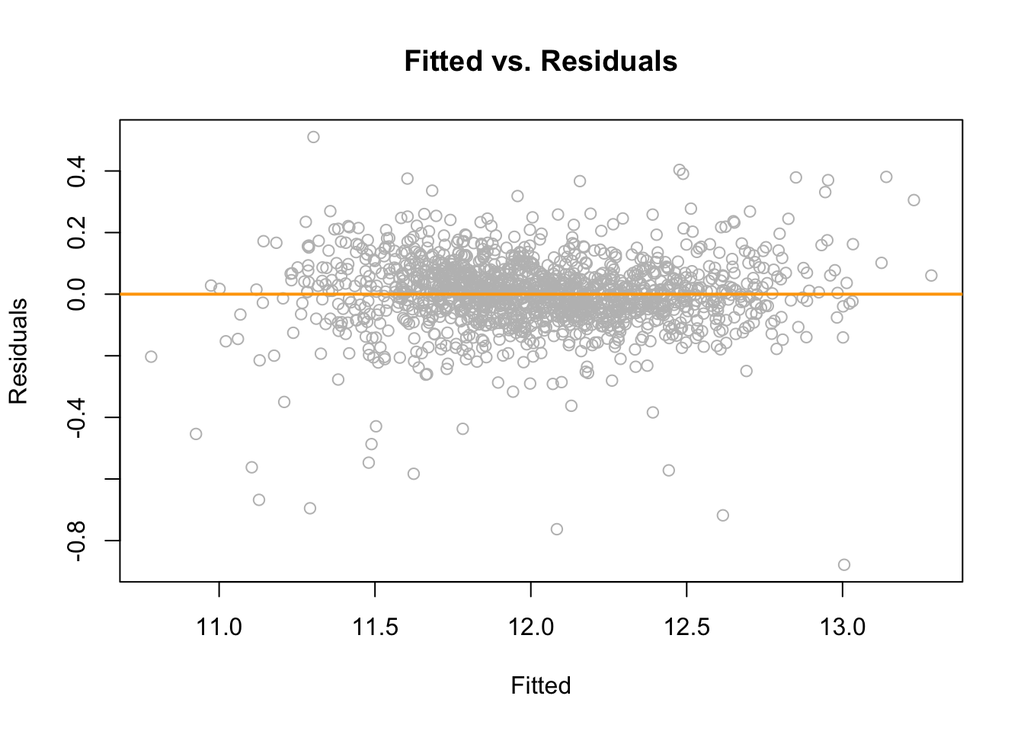

```r
# Fitted vs. Residuals Plot
plot(fitted(best_model), resid(best_model), col = 'grey',
     xlab = "Fitted", ylab = "Residuals", main = "Fitted vs. Residuals")
    abline(h = 0, col = 'orange', lwd = 2)
```

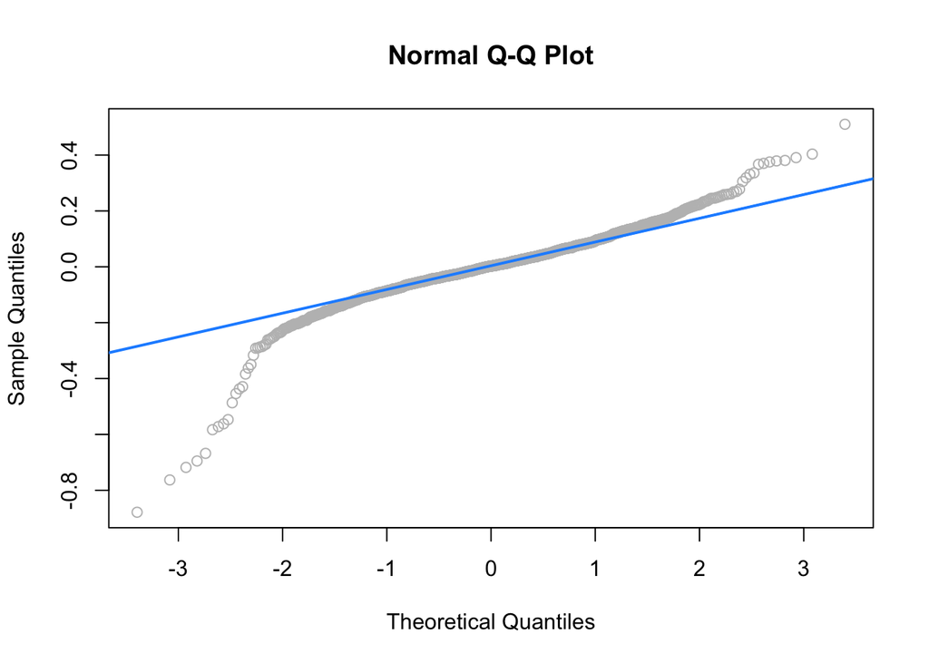

```r
# Q-Q Plot
qqnorm(resid(best_model), main = "Normal Q-Q Plot", col = 'grey')
qqline(resid(best_model), col = 'dodgerblue', lwd = 2)
```

# Discussion

#### Summary of Work

We started with a dataset with a number of missing values and a large number of predictors relative to the number of samples. We fixed the missing values and added some additional factor variables. Next we explored the data to help build intuition we used later when building models.

Then we started with the largest possible additive model and noticed that it was overfitting. We reduced number of predictors using backward selection and BIC and saw an improvement. Then we derived a few additional models using different types of predictor and response tranformations, selecting parameters using backwards BIC as well as the p-values of individual predictor t-tests.

We also tried using interactive predictiors but with such a large number of categorial predictors, we didn’t have much luck.

#### Challenges

The dataset we chose was challenging for a variety of reasons. Because there are so many predictors relative to the number of samples we can easily run into overfitting. If we were able to get more observations we might be able to make use of more of the predictors and have an overall better model. There were also many missing values and useless categories that we needed to deal with.

We have also seen that some of the BIC, train and step functions may take extremely long times - so `caching` was used during development so that we would be able to perform iterative updates to the formatting and text.

#### Final Model

You can tell from the *Prediction vs Observed* plot, the extremely high adjusted $R^2$ value and the low cross validated RMSE that the model is doing an excellent job at predicting home prices. It also uses a fairly small number of predictors (41). We’ve acomplished what we set out to do: build a highly accurate model that’s also interpretable.

None of our models passed the Shapiro-Wilks or Breusch-Pagan tests. However, based on the *Fitted vs. Resuduals* plot, our final model appears to have fairly equal variance. On the other hand, based on the Q-Q plot, it clearly violates the normality assumption.

Some of the notable predictors that become part of selected model are overall quality, year bulit, ground living area, overall contidion, garage area, lot area, among others. Clearly these all play a major role for determining sales price of a home. So we can conclude that selected model is in line with the practical considerations of housing market.

# Acknowledgments

We would like to thank [Professor David Unger](https://stat.illinois.edu/directory/profile/dunger) for his input has been invaluable during the course and lecture hours and also [Professor David Dalpiaz](http://daviddalpiaz.github.io/appliedstats/) for the material that was covered in the course.

We’d also like to thank the incredible army of TAs that did an amazing job answering questions on Piazza and grading our assignments.